# Pitch

Lorenz Hexemer

2022-09-13

# Usecase

- You got tested for a virus infection by a quick test multiple times
- Due to uncertainty in the tests, the result sometimes shows a positive and sometimes a negative result
- Find out which scenario (infected or not) is more likely, given a series of results.

# Manual

- Select the sensitivity and specificity of the quick test.
- Select the result of the test (positive or negative)
- If you used different test, tune sensitivity and specificity
- The app calculates the probability of the given series of events under the two assumptions (infected or not)

# The math behind the app

In the infected scenario, the probability of a series depends on the sensitivity: The Probability of  
the first and the third test beeing positive and the second beeing negative if you are in fact infected is:

```r
  sensi <- 0.73
  p_infected <- prod(c(sensi, 1-sensi,sensi))
  p_infected
```

```
## [1] 0.143883
```

In the healthy scenario, the probability of a series depends on the specificity: The probability of  
the same series of results if you are in fact health is:

```r
  specificity <- 0.93
  p_healthy <- prod(c(1 - specificity,specificity,1-specificity))
  p_healthy
```

```
## [1] 0.004557
```

# A shiny app

The probabilities of the results are also visualized to help you interpreting the results.

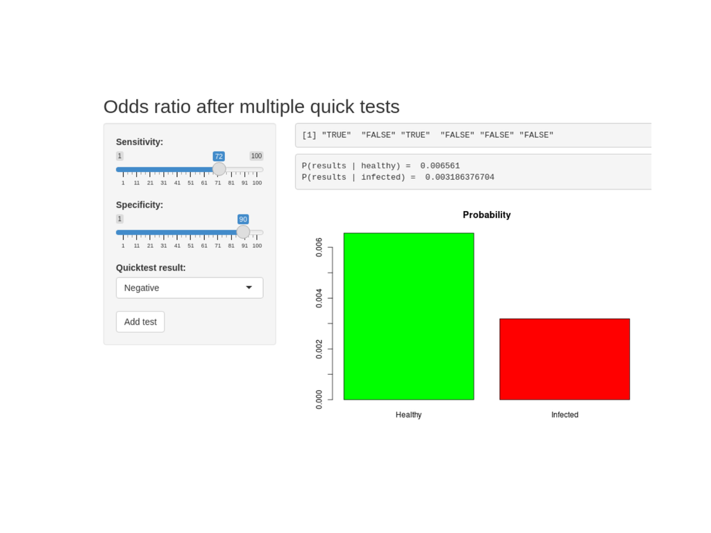